# Hex sticker for {brms.mmrm}

15 April, 2024

## Prerequisites

Load packages:

```r
suppressPackageStartupMessages({
  library(dplyr)
  library(ggplot2)
  library(ggdist)
  library(hexSticker)
  library(sysfonts)
  library(showtext)
})
```

Define colors:

```r
hex_cols <- c("#2b2f44",
              "#edf7f8",
              "#1d6fa7",
              "#f3594d",
              "#204948",
              "#b44b33")
```

Source of color scheme: [Huemint](https://huemint.com/illustration-1/#palette=2b2f44-edf7f8-1d6fa7-f3594d-204948-b44b33)

## Data

Create data for subplot in hex sticker:

```r
set.seed(42)
n <- 10 ^ 4
dat <- expand.grid(
  subject = paste0("pat_", sprintf("%04d", 1:n)) |> factor(),
  visit = c(1, 2, 3, 4) |> factor()
) |>
  mutate(baseline = rnorm(n = n(), mean = 90, sd = 20)) |>
  group_by(subject) |>
  mutate(trt = sample(x = c(0, 1), size = 1)) |>
  ungroup() |>
  mutate(trt = factor(trt)) |>
  arrange(subject, visit)
f <- as.formula(~ -1 + trt:visit)
X <-  model.matrix(object = f, data = data.frame(dat))
betas <- numeric(length = dim(X)[2])
names(betas) <- colnames(X)
betas[1] <- 50
betas[2] <- 50 + 12
betas[3] <- 20
betas[4] <- 20 + 18
betas[5] <- -5
betas[6] <- -5 + 32
betas[7] <- -30
betas[8] <- -30 + 35
err <- rnorm(n = n * 4, mean = 0, sd = 5)
y <-  c(X %*% betas + err)
dat <- bind_cols(dat, "y" = y) |>
  mutate(visit_num = as.numeric(visit),
         chg = y - baseline)
```

## Plot

Create subplot using `{ggplot2}` and `{ggdist}:

### Plot 1

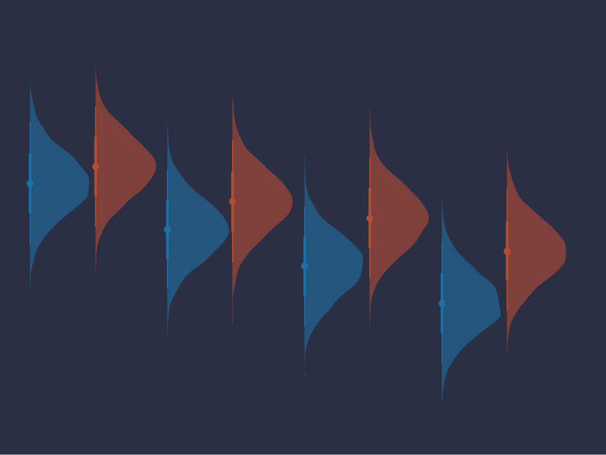

MMRM plot 1.

```r
p1 <- ggplot(data = dat,
             mapping = aes(x = visit,
                           y = chg,
                           fill = trt)) +
  scale_fill_manual(values = alpha(c("0" = hex_cols[3],
                                     "1" = hex_cols[6]), 0.6)) +
  scale_color_manual(values = c("0" = hex_cols[3],
                                "1" = hex_cols[6])) +
  stat_halfeye(mapping = aes(color = trt),
               position = position_dodgejust(width = 0.95)) +
  theme_void() +
  theme(
    panel.grid.major = element_blank(),
    panel.grid.minor = element_blank(),
    legend.position = "none",
    plot.margin = margin(
      t = 5,
      r = 5,
      b = 5,
      l = 5,
      unit = "mm"
    ),
    plot.background = element_rect(fill = hex_cols[1], color = NA)
  )
p1
```

### Plot 2

The distance between the visits (on the x-axis) is now determined by the numeric values of the `visit_num` variable, and can be adjusted using this variable to increase or decrease the distance as per your preference.

```r
vec <- unique(dat$visit_num)
scaling_factor <- 1.35
diffs <- diff(vec)
scaled_diffs <- diffs * scaling_factor
transformed_vec <- c(vec[1], vec[1] + cumsum(scaled_diffs))
unique_visit_num <- sort(unique(dat$visit_num))
replacement <- setNames(object = transformed_vec, nm = unique_visit_num)
replacement
#    1    2    3    4
# 1.00 2.35 3.70 5.05
```

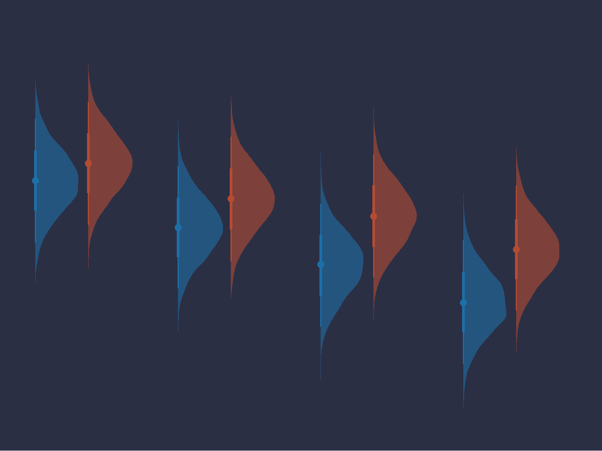

MMRM plot 2.

```r
p2 <- dat |>
  mutate(visit_num = replacement[as.character(visit_num)]) |>
  ggplot(mapping = aes(x = visit_num,
                       y = chg,
                       fill = trt)) +
  scale_fill_manual(values = alpha(c("0" = hex_cols[3],
                                     "1" = hex_cols[6]), 0.6)) +
  scale_color_manual(values = c("0" = hex_cols[3],
                                "1" = hex_cols[6])) +
  stat_halfeye(
    mapping = aes(color = trt),
    width = 0.95,
    position = position_dodgejust(width = 1)
  ) +
  theme_void() +
  theme(
    panel.grid.major = element_blank(),
    panel.grid.minor = element_blank(),
    legend.position = "none",
    plot.margin = margin(
      t = 3,
      r = 3,
      b = 3,
      l = 3,
      unit = "mm"
    ),
    plot.background = element_rect(fill = hex_cols[1], color = NA)
  ) +
  scale_x_continuous(breaks = unique(dat$visit_num),
                     labels = unique(dat$visit))
p2
```

## Hex sticker

Create hex sticker using `{hexSticker}` with a custom [Google font](https://fonts.google.com/):

[figure not shown]

Hex sticker.

```r
font_add_google(name = "Urbanist", family = "custom_font")
showtext_auto()
s <- sticker(
  p2,
  package = "brms.mmrm",
  p_size = 8,
  s_x = 1,
  s_y = 0.8,
  s_width = 8 / 4.5,
  s_height = 6 / 4.5,
  filename = "hex_sticker.svg",
  p_fontface = "bold",
  p_family = "custom_font",
  h_fill = hex_cols[1],
  h_color = hex_cols[5],
  p_color = hex_cols[2],
  dpi = 600
)
s
```

Remove image file automatically generated by `sticker()`:

```r
file.remove("hex_sticker.svg")
# [1] TRUE
```

Save hex sticker as pdf:

```r
ggsave(
  filename = "brms_mmrm_hex1.pdf",
  plot = s,
  width = 3,
  height = 3.47155255544841,
  device = "pdf",
  dpi = 600
)
```

Note that the font size in the svg and the pdf (not shown in rendered output) is slightly different.

The file `brms_mmrm_hex1.pdf` will be further processed using graphics software and exported as an svg file. This is mainly done to clip the subplot using the hexagon shape as clipping mask.

The resulting file (`brms_mmrm_hex2.svg`) can then be added to the package, e.g. using `usethis::use_logo()` which will store (a smaller version of) it in the folder `man/figures`. Image files with different sizes and formats can be generated using `pkgdown::build_favicons()`.